### “Weight Lifting Data Prediction”

#### Background:

Data collected from wearable devices such as fitbit, fuelband was used to quantify how well a perticular activity was performed by the users. This perticular data was from 6 participants who performed barbel lifts correctly and incorrectly in 5 different ways. More information is available from the source below.

Source & Credits: http://groupware.les.inf.puc-rio.br/har

#### Objective:

Goal is to predict the manner in which the exercise was performed. This is determined by the “classe” variable in the training set.

#### Loading Data

The training data for this project are available here: https://d396qusza40orc.cloudfront.net/predmachlearn/pml-training.csv

The test data are available here: https://d396qusza40orc.cloudfront.net/predmachlearn/pml-testing.csv

```r
DF <- read.csv("pml-training.csv", header=TRUE, na.strings="")
testing<-read.csv("pml-testing.csv", header=TRUE, na.strings="")
```

#### Pre-processing

We identify and remove the columns with NA values as they don’t make good predictors.

```r
DF[DF == '' | DF == 'NA'] <- NA
indexes <- which(colSums(is.na(DF))!=0)
preprocessedDF <- DF[,-indexes]
# Also removed the columns like time stamps and factor variables with less than 2 levels.
preprocessedDF <-preprocessedDF[,-(1:7)]
```

#### Fitting the Model

Since the prediction is for a classification, Random forests method can be our best bet to start with. Below, we fit the model using “caret” package and its built in functions for partitioning dataset and also fitting the model.

```r
set.seed(1234)
library(caret) ; library(e1071)
indexPartition <- createDataPartition(y=preprocessedDF$classe, p=0.7, list=FALSE)
training <- preprocessedDF[indexPartition,]
validation <- preprocessedDF[-indexPartition,]
modFit <- train(classe~., data=training, method = "rf",tuneLength = 1, ntree = 25, trControl=trainControl( method="oob",verboseIter=FALSE,allowParallel=TRUE))
```

Random Forest model was fit using 52 predictors and 13737 samples to predict the classe variable with 5 classes A,B,C,D,E.

In random forests, there is no need for cross-validation or a separate test set to get an unbiased estimate of the test set error. It is estimated internally, during the run based on the Out-of-bag error in the resample.

#### Model Performance

Now let us see how the model we built performed the predictions:

```r
pred <- predict(modFit,validation)
confusionMatrix(pred,validation$classe)
```

```
## Confusion Matrix and Statistics
##
##           Reference
## Prediction    A    B    C    D    E
##          A 1672   10    0    0    0
##          B    0 1129    7    0    1
##          C    1    0 1016    7    2
##          D    1    0    3  955    0
##          E    0    0    0    2 1079
##
## Overall Statistics
##
##                Accuracy : 0.994
##                  95% CI : (0.992, 0.996)
##     No Information Rate : 0.284
##     P-Value [Acc > NIR] : <2e-16
##
##                   Kappa : 0.993
##  Mcnemar's Test P-Value : NA
##
## Statistics by Class:
##
##                      Class: A Class: B Class: C Class: D Class: E
## Sensitivity             0.999    0.991    0.990    0.991    0.997
## Specificity             0.998    0.998    0.998    0.999    1.000
## Pos Pred Value          0.994    0.993    0.990    0.996    0.998
## Neg Pred Value          1.000    0.998    0.998    0.998    0.999
## Prevalence              0.284    0.194    0.174    0.164    0.184
## Detection Rate          0.284    0.192    0.173    0.162    0.183
## Detection Prevalence    0.286    0.193    0.174    0.163    0.184
## Balanced Accuracy       0.998    0.995    0.994    0.995    0.998
```

The model accuracy is over 98% with a statistically significant P-value.

#### Project Submission

```r
answers <- predict(modFit, testing)
```

#### Extras

##### Correlation Plot for further feature selection/reduction

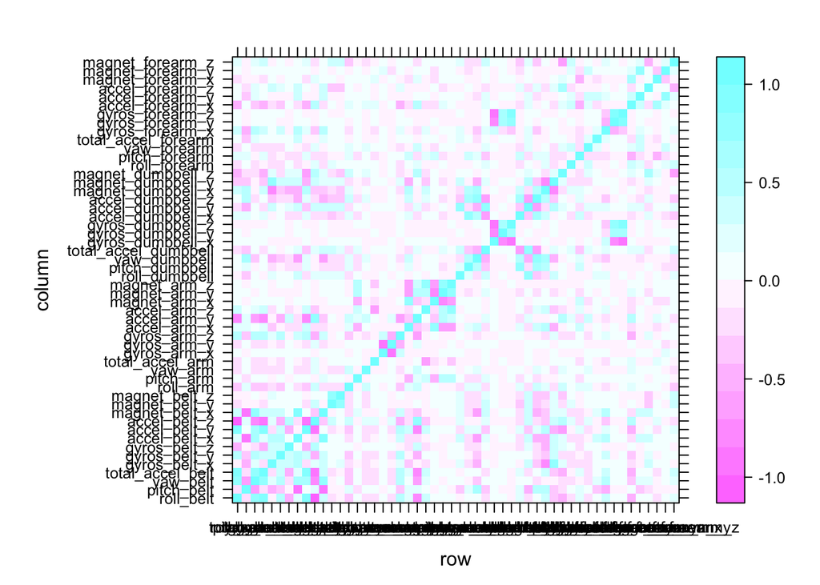

```r
require(lattice)
z <- cor(training[,-53])
levelplot(z)
```